# Predicting Customer Credit Label using Classification Trees

Mark Preston

August 1, 2018

## Customer Creditability using German Credit Data

As a continuation from the logistic regression prediction, I’ll be using the German Credit data to predict whether a customer should labeled as good or bad from a credit perspective. However, this assignment will utilize classification trees for predictions instead. I’ve also carried over the same training and holdout from the previous work as well.

```r
library(tidyverse)
library(caret)
library(rattle)
library(directlabels)
library(rpart)
library(knitr)
library(kableExtra)

#ggplot plotting theme preference
theme_set(
  theme_minimal()
)

#custom table function used throughout analysis
custom_kable <- function(x){
  kable(x, format = "html") %>%
    kable_styling(bootstrap_options = "striped")
}

training <- read.csv("german_train.csv")
factors <- training %>%
  select(-1:-7) %>%
  map_df(as.factor)

training <- training %>%
  select(1:7) %>%
  bind_cols(factors)

holdout <- read.csv("german_holdout.csv")
factors <- holdout %>%
  select(-1:-7) %>%
  map_df(as.factor)

holdout <- holdout %>%
  select(1:7) %>%
  bind_cols(factors)
```

### Build a Classification Tree to predict Class on the training set

Below, I’ve developed the initial classification tree. The tree control parameters are set so the tree grows to full size (complexity parameter of zero) with terminal nodes that have at least thirty observations (minsplit = 30). Additionally, the model has 10-fold cross validation.

```r
set.seed(1017)

tree_params <- rpart.control(cp = 0, minsplit = 30, xval = 10)

credit_tree <- rpart(Class ~., data = training, control = tree_params)
```

### Evaluate the complexity parameter plots and print out. Prune tree using cp value corresponding to the lowest xerror

The `plotcp` function returns the model’s complexity parameter, relative error, and size of tree. Here, I’m looking for the lowest x error value and the corresponding complexity, which is then used to prune the initial tree. With this in mind, it looks like the complexity parameter will be around .02.

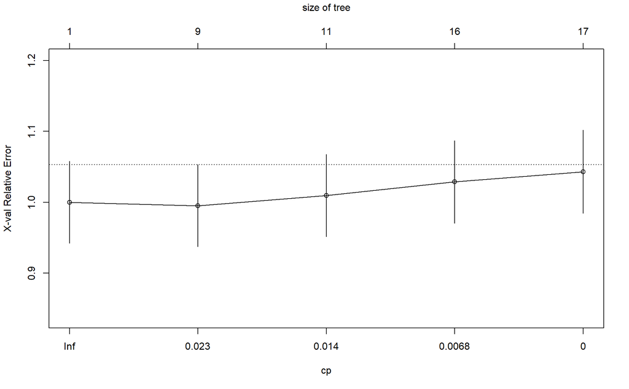

```r
plotcp(credit_tree)
```

The complexity parameter table confirms the visualization. The lowest x error is associated with a cp of about .02. This value will be carried forward to prune the tree.

```r
cp_table <- as.data.frame(credit_tree$cptable) %>%
  arrange(xerror)

cp_table %>%
  custom_kable()
```

| CP | nsplit | rel error | xerror | xstd |
| --- | --- | --- | --- | --- |
| 0.0191388 | 8 | 0.6889952 | 0.9952153 | 0.0578521 |
| 0.0287081 | 0 | 1.0000000 | 1.0000000 | 0.0579320 |
| 0.0095694 | 10 | 0.6507177 | 1.0095694 | 0.0580899 |
| 0.0047847 | 15 | 0.6028708 | 1.0287081 | 0.0583976 |
| 0.0000000 | 16 | 0.5980861 | 1.0430622 | 0.0586214 |

Using the `prune` function, I’ve taken the complexity parameter from the previous table and reduced the tree. With this done, the final model for the training set is ready to review.

```r
set.seed(1017)

credit_pruned <- prune(tree = credit_tree, cp = cp_table$CP[1])

printcp(credit_pruned)
```

```
##
## Classification tree:
## rpart(formula = Class ~ ., data = training, control = tree_params)
##
## Variables actually used in tree construction:
## [1] Account.Balance      Duration             Occupation
## [4] Previous_Credit_Pay  Purpose              Value.Savings.Stocks
##
## Root node error: 209/700 = 0.29857
##
## n= 700
##
##         CP nsplit rel error  xerror     xstd
## 1 0.028708      0     1.000 1.00000 0.057932
## 2 0.019139      8     0.689 0.99522 0.057852
```

Before the formal prediction, there is an interesting inclusion in the tree object. The model has a variable importance rating. Essentially, a high score outlines the information loss associated with the variable if it was dropped. Prior to looking at the actual tree, this provides a very good indicator of what feature is driving the prediction results.

As the plot shows, there are six variables included in the final model from the intial 20. It also essentially outlines that if the data could be best described with one variable, it would be account balance. Intuitively, I think this makes sense given there would be an expectation that customers with good creditablility have an upstanding account balance. While I haven’t plotted the tree itself, this shows account balance is very likely the main node. A quick scan of the other variables also show variables I would associate with being a good customer, like the value of their savings.

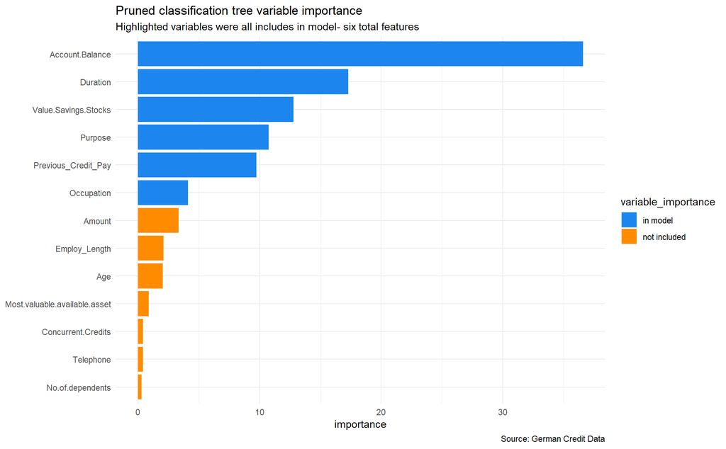

```r
tree_importance <- as.data.frame(credit_pruned$variable.importance) %>%
  rownames_to_column(var = "tree_vars") %>%
  rename(importance = "credit_pruned$variable.importance")

tree_importance %>%
  mutate(tree_vars = reorder(tree_vars, importance),
         variable_importance = c(rep("in model", 6), rep("not included", 7))) %>%
  ggplot(aes(tree_vars, importance, fill = variable_importance)) +
  geom_col() +
  coord_flip() +
  scale_fill_manual(values = c("dodgerblue2", "darkorange")) +
  labs(title = "Pruned classification tree variable importance",
       subtitle = "Highlighted variables were all includes in model- six total features",
       x = NULL,
       caption = "Source: German Credit Data")
```

### Develop a confusion matrix for the training set using the pruned tree

The pruned model shows about 79% accuracy on the intial training data. Perhaps equally important given the bank’s desire for high sensitivity, the model shows about 79% here. Overall, the main accuracy metrics are very balanced, which is a good trait. However, trees are prone to overfitting so the holdout accuracy review will be more illuminating.

```r
training <- training %>%
  mutate(tree_pred = predict(object = credit_pruned,
                              newdata = training,
                              type = "class"))

confusionMatrix(training$Class, training$tree_pred)
```

```
## Confusion Matrix and Statistics
##
##           Reference
## Prediction   0   1
##          0  88 121
##          1  23 468
##
##                Accuracy : 0.7943
##                  95% CI : (0.7624, 0.8237)
##     No Information Rate : 0.8414
##     P-Value [Acc > NIR] : 0.9996
##
##                   Kappa : 0.4324
##  Mcnemar's Test P-Value : 6.302e-16
##
##             Sensitivity : 0.7928
##             Specificity : 0.7946
##          Pos Pred Value : 0.4211
##          Neg Pred Value : 0.9532
##              Prevalence : 0.1586
##          Detection Rate : 0.1257
##    Detection Prevalence : 0.2986
##       Balanced Accuracy : 0.7937
##
##        'Positive' Class : 0
##
```

#### Can you observe any signifigant tree interactions? Does the tree look useful?

The tree plot confirms the variable importance plot showing account balance as the initial node. Any account balance of 3 or 4 (higher balances essentially) are classified as being good customers; this split yields an 87% accuracy, which is quite high even in comparison to the intitial 70% of customers being good. Additionally, the main split accounts for about 46% of the training cases, or 322 customers.

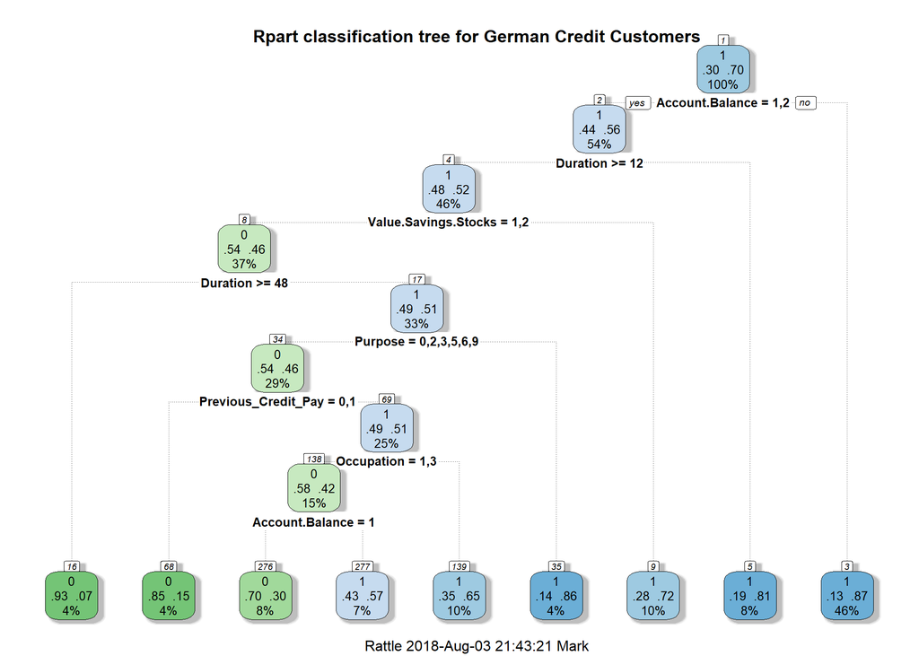

```r
fancyRpartPlot(credit_pruned,
               type = 2,
               cex = .83,
               main = "Rpart classification tree for German Credit Customers")
```

### Perform holdout validation using a confusion matrix

```r
holdout <- holdout %>%
  mutate(tree_pred = predict(object = credit_pruned,
                              newdata = holdout,
                              type = "class"))

confusionMatrix(holdout$Class, holdout$tree_pred)
```

```
## Confusion Matrix and Statistics
##
##           Reference
## Prediction   0   1
##          0  25  66
##          1  23 186
##
##                Accuracy : 0.7033
##                  95% CI : (0.6481, 0.7545)
##     No Information Rate : 0.84
##     P-Value [Acc > NIR] : 1
##
##                   Kappa : 0.19
##  Mcnemar's Test P-Value : 8.508e-06
##
##             Sensitivity : 0.52083
##             Specificity : 0.73810
##          Pos Pred Value : 0.27473
##          Neg Pred Value : 0.88995
##              Prevalence : 0.16000
##          Detection Rate : 0.08333
##    Detection Prevalence : 0.30333
##       Balanced Accuracy : 0.62946
##
##        'Positive' Class : 0
##
```

### Summarize the results. Did the logistic regression or classification tree perform better on the German Credit data?

When comparing both methods, I think the logistic model provided better predictions given its range of balanced accuracy metrics. The tree model showed signs of overfitting, which is common for the method but, hurts its usefulness for predictions. Additionally, the bank expressed an interest in having a model with high sensitivty, which is another knock against the tree model.

Overall, I think the logistic model is preferable but, I do like the transparency and visual simplicity of the tree. While logistic models are reasonably interpretable, working with log odds isn’t always straightforward. This is especially true when trying to describe results to a non-technical stakeholder. As such, I think the tree model has better interpretability and presentation value. However, the main component of the assignment is predictive power and not inferential work, so my choice is the logistic model.